# Frequency Distributions

Table of Contents:

- Introduction
  - Tools
- Pronouns
  - Forms
  - Possession
- Conclusion

# Introduction

This note will explain how to analyze a document based on the frequencies distributions of the document's vocabulary. Such word frequency distributions can give interesting insights about the document, answering questions like "Are there implicit biases within the text?" and "Is this text actually written by the specified author?"

For simplicity, this note will only scratch the surface of finding such distributions, avoiding some of the heavy analysis (let's leave that to the experts).

## Tools

We will be using the Python `nltk`-library for both our data and main functions. The common libraries `numpy` and `matplotlib.pylot` will also be used. These can be installed using the `pip`-installer.

```python
# pip install nltk
# pip install numpy
# pip install matplotlib
```

```python
from nltk.corpus import brown
import nltk
import numpy as np
import matplotlib.pyplot as plt
import pandas as pd
%matplotlib inline
```

For our data, we will use the **[Brown Corpus](https://en.wikipedia.org/wiki/Brown_Corpus)** which comes with installation of [`nltk`](https://www.nltk.org/howto/corpus.html). Curated in 1961, this corpus was the first of it's kind and "set the bar for the scientific study of the frequency and distribution of word categories in everyday language use". This historical context is important to keep in mind when analyzing specific attributes of the corpus, as historical texts often carry with them the biases of the cultures they were produced in. More details on the Brown Corpus and be found at it's [wiki page](https://en.wikipedia.org/wiki/Brown_Corpus).

# Pronouns

Our experiment will look into the numbers of masculine pronouns (he, him) versus feminine pronouns (she, her) found in the Brown Corpus. The words of the corpus are found using the `nltk.corpus.brown.words()` method. We use the `nltk.FreqDist()` to quickly count the occurrences of our 4 pronouns:

```python
pronouns = ['he', 'him', 'she', 'her']
```

```python
brown_freq = nltk.FreqDist(
    [w for w in brown.words() if w in pronouns]
)

brown_freq
```

```
FreqDist({'he': 6566, 'her': 2885, 'him': 2576, 'she': 1949})
```

We already see an imbalance between the representation of the two pronoun types. Remember, this corpus includes only texts produced before 1961. Therefore, this misrepresentation merely reflects the societal views of the two genders at the time of production.

It could still be interesting to see how this imbalance changes between the different genres labeled in the Brown corpus. For now, we will look specifically at: news, religion, government, fiction, romance.

```python
genres = ['news', 'religion', 'government', 'fiction', 'romance']
```

Let's label each word in the corpus with it's respective genre to start. Specifying the genre can be done using parameter `categories` when calling `corpus.words()`.

```python
genre_words = [(genre, word)
                for genre in genres
                for word in brown.words(categories=genre)]
genre_words[:10]
```

```
[('news', 'The'),
 ('news', 'Fulton'),
 ('news', 'County'),
 ('news', 'Grand'),
 ('news', 'Jury'),
 ('news', 'said'),
 ('news', 'Friday'),
 ('news', 'an'),
 ('news', 'investigation'),
 ('news', 'of')]
```

Sweet! Now, our list `genre_words` is ready to sorted and counted. This sorting by tag is achieved using `nltk.ConditionalFreqDist()`, a derivation of the method used earlier.

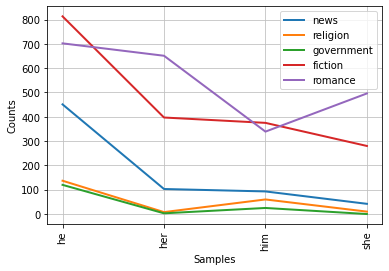

```
            he her him she
   fiction 813 397 375 280
government 120   3  25   0
      news 451 103  93  42
  religion 137   8  60  10
   romance 702 651 339 496
```

```python
cfd = nltk.ConditionalFreqDist(
    [word for word in genre_words if word[1] in pronouns]
)
cfd.plot()
cfd.tabulate()
```

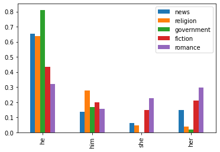

```python
cfd_std = pd.DataFrame(cfd)/pd.DataFrame(cfd).sum(axis=0) # standardize the counts
cfd_std.plot.bar() # easier to read than the built-in plot method of cfd
```

The plots and the table give an idea of how the occurrences of our 4 chosen pronouns vary between the genres we are looking at. Let's now group these results based on the pronouns' respective gender identity. This process can be hard coded as a nested for loop, iterating through the genres and pronouns in the `cfd` variable created above.

```python
def group_by_gender(cfd=cfd):
    grouped = {}
    for g in cfd.keys():
        m = 0
        f = 0
        for p in cfd[g].keys():
            d = {}

            if p in ['he', 'him']:
                m += cfd[g][p]
            else:
                f += cfd[g][p]
        grouped[g] = {
            'masculine': m,
            'feminine': f
        }
    return grouped

grouped_cdf = group_by_gender(cfd)
```

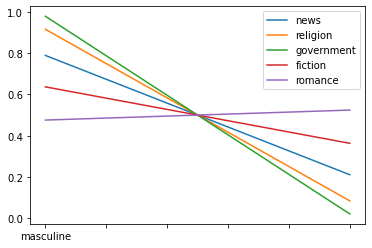

```python
grouped_cfd_std = pd.DataFrame(grouped_cfd)/pd.DataFrame(grouped_cfd).sum(axis=0) # standardize the counts
grouped_cfd_std.plot()
```

|  | news | religion | government | fiction | romance |
| --- | --- | --- | --- | --- | --- |
| masculine | 0.78955 | 0.916279 | 0.97973 | 0.636997 | 0.475777 |
| feminine | 0.21045 | 0.083721 | 0.02027 | 0.363003 | 0.524223 |

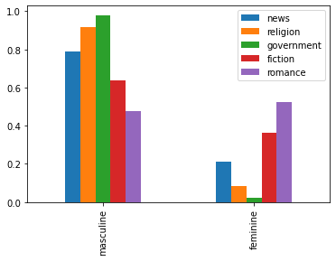

```python
grouped_cfd_std.plot.bar()
grouped_cfd_std
```

These distributions show that not all categories use more masculine pronouns than feminine. Although, the fact that the only genre with more feminine pronouns than masculine being romance emphasizes the assumption of bias within this dataset. Ironically, this genre is also the most balanced, since it has the flattest slope in the first plot.

The genre with the greatest relative difference in use of masculine to feminine pronouns was government. As can be read in the table, only 2% of the pronouns used were feminine for this genre.

# Pronoun forms

We continue now by analyzing the occurrences of the different *forms* in which the gender pronouns take on.

Formally speaking, we want to see if the relative frequency of the objective form, *her,* within the feminine personal pronouns is higher than the relative frequency of the objective form, *him,* within the masculine personal pronouns.

This will give us an idea of how the gender pronouns are used in English.

```python
nominative = ['he', 'she']
objective  = ['him', 'her']
masculine  = ['he', 'him']
feminine   = ['she', 'her']
```

```python
cfd_std.transpose()
```

|  | he | him | she | her |
| --- | --- | --- | --- | --- |
| news | 0.654572 | 0.134978 | 0.060958 | 0.149492 |
| religion | 0.637209 | 0.279070 | 0.046512 | 0.037209 |
| government | 0.810811 | 0.168919 | NaN | 0.020270 |
| fiction | 0.435925 | 0.201072 | 0.150134 | 0.212869 |
| romance | 0.320841 | 0.154936 | 0.226691 | 0.297532 |

We'll need to sort by pronoun type and gender. This process can be executed using a conditional for loop.

```python
forms = []
for word in brown.words():
    if word in pronouns:
        if word in nominative:
            form = 'nominative'
        else:
            form = 'objective'
        if word in masculine:
            gender = 'masculine'
        else:
            gender = 'feminine'
        forms.append((form, gender))
forms[:3]
```

```
[('nominative', 'masculine'),
 ('nominative', 'masculine'),
 ('objective', 'masculine')]
```

Our tagged list can be given to the same method used above.

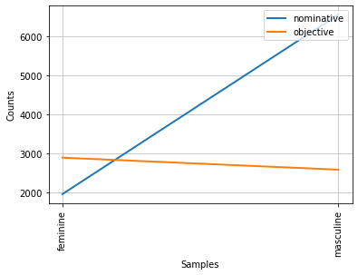

```python
forms_cfd = nltk.ConditionalFreqDist(forms)
forms_cfd.plot()
```

```python
pd.DataFrame(forms_cfd)/pd.DataFrame(forms_cfd).sum(axis=0)
```

|  | nominative | objective |
| --- | --- | --- |
| masculine | 0.77111 | 0.471708 |
| feminine | 0.22889 | 0.528292 |

```python
pd.DataFrame(forms_cfd).transpose()/pd.DataFrame(forms_cfd).sum(axis=1)
```

|  | masculine | feminine |
| --- | --- | --- |
| nominative | 0.718224 | 0.403186 |
| objective | 0.281776 | 0.596814 |

From the plot above, it seems that the initial hypothesis was in fact correct. The feminine objective pronoun *her* is used more frequently than the nominative *she,* whereas the opposite can be observed for the masculine objective and nominative pronouns, *him* and *he* respectively.

The two tables explain this scenario from two different points of view. The first table says that when looking at all the nominative pronouns in the text, 77% are masculine and 23% are feminine, whereas the objective pronouns are balanced between the two genders. The second table shows that out of all the masculine pronouns used, 72% are nominative and 28% are objective. When looking at the feminine pronouns, the split between nominative and objective is closer to 40%-60%, respectively. This tells us that the English language (per 1961) is heavily diluted with the masculine, nominative pronoun *he*.

This doesn't tell us the whole truth though, since *her* is the feminine equivalent of both *his* and *him.* In other words, our specific selection of pronouns is very strict, and fails capture all lexemme of the gender pronouns, arbitrarily.

To take this into account, we could expand our search for occurrences of `'his'+'him'` versus those of `'her'+'hers'`. This way we could count all of the objective forms for both genders, instead of the non-possessive. This exercise can be left up to the reader.

# Possessive pronouns

Another way of separating the two objective forms is to use a tagged corpus, which separates between the two forms of her, i.e, if the corpus tags her as a personal pronoun differently from her as a possessive pronoun. The tagged Brown corpus with the full tag set does that.

We will use this to count the occurrences of she, he, her, him as personal pronouns and her, his, hers as possessive pronouns.

A table presenting the pronoun tags found in the Brown corpus is listen below. The full table can be found [here](https://en.wikipedia.org/wiki/Brown_Corpus#Part-of-speech_tags_used).

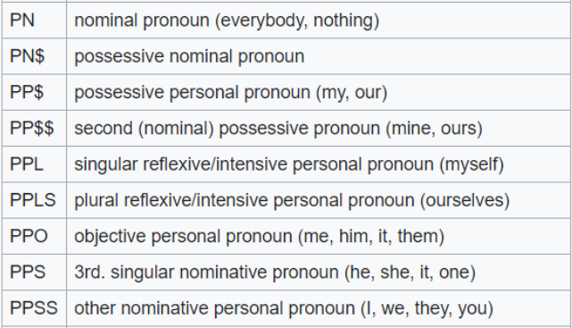

```python
pronouns += ['hers', 'his']
pronouns
```

```
['he', 'him', 'she', 'her', 'hers', 'his']
```

```python
wanted_tags = ['PN$', 'PP$', 'PPO','PP$$', 'PPS']
tag_words = [x for x in brown.tagged_words()
             if (x[0] in pronouns and x[1] in wanted_tags)]
```

```python
tcfd = nltk.ConditionalFreqDist(tag_words)
tcfd.tabulate()
```

```
      PP$ PP$$  PPO  PPS
  he    0    0    0 6561
 her 1775    0 1106    0
hers    0   16    0    0
 him    0    0 2572    0
 his 6418   36    0    0
 she    0    0    0 1946
```

```python
masculine += ['his']
feminine  += ['hers']
```

```python
pps_ppo = pd.DataFrame(tcfd)
```

```python
pps_ppo.index = ['PPs', 'PPss', 'PPS', 'PPO']
```

|  | masculine | feminine |
| --- | --- | --- |
| PPs | 6418.0 | 1775.0 |
| PPss | 36.0 | 16.0 |
| PPS | 6561.0 | 1946.0 |
| PPO | 2572.0 | 1106.0 |

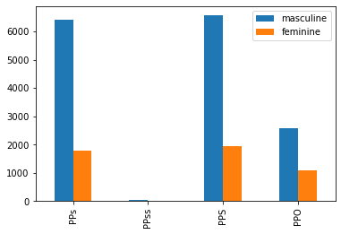

```python
grouped_pps_ppo = pd.concat([pps_ppo[masculine].sum(axis=1),pps_ppo[feminine].sum(axis=1)],  axis=1)
grouped_pps_ppo.columns = ['masculine', 'feminine']
grouped_pps_ppo.plot.bar()
grouped_pps_ppo
```

```python
grouped_pps_ppo/grouped_pps_ppo.sum(axis=0)
```

|  | masculine | feminine |
| --- | --- | --- |
| PPs | 0.411753 | 0.366508 |
| PPss | 0.002310 | 0.003304 |
| PPS | 0.420928 | 0.401817 |
| PPO | 0.165009 | 0.228371 |

```python
grouped_pps_ppo.transpose()/grouped_pps_ppo.sum(axis=1)
```

|  | PPs | PPss | PPS | PPO |
| --- | --- | --- | --- | --- |
| masculine | 0.783352 | 0.692308 | 0.771247 | 0.699293 |
| feminine | 0.216648 | 0.307692 | 0.228753 | 0.300707 |

These distributions resemble those found in the first distributions found in this project.

# Conclusion

In the first part of this exercise, we found that masculine pronouns were a lot more common than feminine pronouns, across almost all genres. This reflects women's historical place in society and helps illustrate that language can carry with it the biases of previous generations.

In reference to the use of nominative pronouns versus objective pronouns across the two genders, it first seemed as though feminine pronouns were more likely to be objective than masculine. However, as was shown through further analysis, this great difference was likely due to the distinction between possessive and objective personal pronouns for the masculine pronouns ‘his’ and ‘him’, whereas feminine pronouns of these two forms were grouped together as ‘her’.

When working with language technologies, these biases must be taken into consideration, so as to not build predictive models where certain groups can be discriminated against. It’s important to note that the Brown Corpus was the first representation of the English language as a whole, per 1961. This was a historically different time than where society is today, especially when taking into consideration the Civil Rights movement of the 60’s and 70’s, as well as antidiscrimination efforts and laws that have grown drastically in popularity within the past few decades.

Language technologists must make sure to be using as up to date representations of the languages they modeling to both correctly represent the language, and to follow suite with the societal changes inflicted upon the language.